# TikTok_Live_Data_Analysis

## Step 1: Importing Libraries

In this step, I import the libraries needed for my analysis. `pandas` is used for reading and cleaning the data, and `matplotlib.pyplot` is used for creating graphs.

The reason I use `import pandas as pd` is to give it a short alias, so I can use `pd.read_excel()` instead of typing the full library name. As well as, 'import matplotlib.pyplot as plt' so that I can refer to it as plt through out this code.

```python
import pandas as pd # pandas is used to work with tabular data
import matplotlib.pyplot as plt # matplotlib is used for making visualisations
```

## Step 2: What Rendering Engine I am Using

In this step, I am going to use the the rendering engine as I want to create a display chart and matplotlib is perfect - for creating data visualisations.

```python
import matplotlib
matplotlib.get_backend() # this returns the name of the backend (rendering engine) matplotlib uses to display plots. Helpful for troubleshooting why a graph might not appear.
```

```
'module://matplotlib_inline.backend_inline'
```

## Step 3: Loading the Excel File

In this step, I am loading the cleaned dataset from Excel using `pandas.read_excel()`. This allows me to analyse the data in Python. The goal is to import the same dataset I worked with in Excel, so I can use it for further exploration and visualization.

I'm only working with the sheet that contains weekly performance data.

```python
# Load the Excel file and view the sheet names
excel_file = pd.ExcelFile(r"C:\Users\Hajira\Documents\TikTok_Raw_Data_Tracker Updated.xlsx")
excel_file.sheet_names
```

```
['Average Views Per Week ',
 'Average Engagement Score P.W',
 'Growth and Engagement Tracker',
 'Raw Data']
```

## Step 4: Cleaning and Exploring the Data

Before plotting any graphs, it's important to understand what the data looks like. I use `df.head()` to view the first few rows. I will also check for missing values, data types, and any columns I may want to convert or rename.

```python
# Read the relevant sheet — change the name to match your weekly summary sheet name
df = pd.read_excel(excel_file, sheet_name='Growth and Engagement Tracker')

# Preview the data
df.head()  # shows the first 5 rows so I can check the structure and column names
```

|  | Unnamed: 0 | Date Posted | Engagement Level (Low/Med/High) | Views | Likes | Follow | Gifters | Comments | Shares | Duration (if Live) | Engament Score % | Cumulative Views | % Growth | Week Number |
| --- | --- | --- | --- | --- | --- | --- | --- | --- | --- | --- | --- | --- | --- | --- |
| 0 | NaN | 2025-04-19 | 63.833333 | 220 | 161 | 0 | 0 | 2 | 0 | 1hr 7mins | 74.090909 | 63.833333 | -65.000000 | 2025-W16 |
| 1 | NaN | 2025-04-19 | 39.000000 | 77 | 146 | 0 | 0 | 11 | 0 | 1hr 11mins | 203.896104 | 102.833333 | -9.090909 | 2025-W16 |
| 2 | NaN | 2025-04-20 | 13.166667 | 70 | 0 | 0 | 0 | 0 | 9 | 59 mins | 12.857143 | 116.000000 | -17.142857 | 2025-W16 |
| 3 | NaN | 2025-04-25 | 11.166667 | 58 | 0 | 0 | 0 | 9 | 0 | 1hr 15mins | 15.517241 | 127.166667 | -13.793103 | 2025-W17 |
| 4 | NaN | 2025-04-27 | 175.000000 | 50 | 1000 | 0 | 0 | 0 | 0 | 57 mins | 2000.000000 | 302.166667 | 220.000000 | 2025-W17 |

## Step 5: Check for Missing Values, Data Types

If I find missing values, I may decide to fill them in, remove them, or replace them. In this case, I expect the weekly data to be clean as it was cleaned in Excel earlier.

```python
# Check data types
df.info()  # shows column names, number of non-null values, and data types

# Check for missing values
df.isnull().sum()  # shows how many missing values there are per column
```

```
<class 'pandas.core.frame.DataFrame'>
RangeIndex: 48 entries, 0 to 47
Data columns (total 14 columns):
 #   Column                           Non-Null Count  Dtype
---  ------                           --------------  -----
 0   Unnamed: 0                       0 non-null      float64
 1   Date Posted                      48 non-null     datetime64[ns]
 2   Engagement Level (Low/Med/High)  48 non-null     float64
 3   Views                            48 non-null     int64
 4   Likes                            48 non-null     int64
 5   Follow                           48 non-null     int64
 6   Gifters                          48 non-null     int64
 7   Comments                         48 non-null     int64
 8   Shares                           48 non-null     int64
 9   Duration (if Live)               48 non-null     object
 10  Engament Score %                 48 non-null     float64
 11  Cumulative Views                 48 non-null     float64
 12  % Growth                         48 non-null     float64
 13  Week Number                      48 non-null     object
dtypes: datetime64[ns](1), float64(5), int64(6), object(2)
memory usage: 5.4+ KB
```

```
Unnamed: 0                         48
Date Posted                         0
Engagement Level (Low/Med/High)     0
Views                               0
Likes                               0
Follow                              0
Gifters                             0
Comments                            0
Shares                              0
Duration (if Live)                  0
Engament Score %                    0
Cumulative Views                    0
% Growth                            0
Week Number                         0
dtype: int64
```

I use the pandas `.pct_change()` method, which compares each row to the previous one and gives the relative change as a decimal. Multiplying by 100 converts it to a percentage.

This helps me identify trends — whether views are increasing, decreasing, or holding steady over time.

```python
# make sure data is sorted by date
df = df.sort_values("Date Posted")

# Calculate percentage growth of Views compared to previous week
df['Views_Pct_Growth'] = df['Views'].pct_change()*100

# Preview the result (first 10 rows)
df[['Date Posted', 'Views', 'Views_Pct_Growth']].head(10)
```

|  | Date Posted | Views | Views_Pct_Growth |
| --- | --- | --- | --- |
| 0 | 2025-04-19 | 220 | NaN |
| 1 | 2025-04-19 | 77 | -65.000000 |
| 2 | 2025-04-20 | 70 | -9.090909 |
| 3 | 2025-04-25 | 58 | -17.142857 |
| 4 | 2025-04-27 | 50 | -13.793103 |
| 5 | 2025-04-28 | 160 | 220.000000 |
| 6 | 2025-04-29 | 88 | -45.000000 |
| 7 | 2025-05-01 | 100 | 13.636364 |
| 8 | 2025-05-02 | 156 | 56.000000 |
| 9 | 2025-05-03 | 175 | 12.179487 |

## Step 7: Visualize TikTok Views Over Time

Next, I create a line chart showing how the number of views changes over time.

The X-axis represents the dates of my TikTok Lives, and the Y-axis shows the corresponding views for each live.

This visual allows me to quickly spot patterns, spikes, or drops in engagement, which I can investigate further.

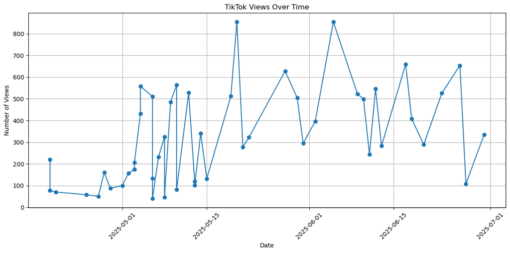

```python
import matplotlib.pyplot as plt  # make sure this import is at the top of your notebook

plt.figure(figsize=(12,6))
plt.plot(df['Date Posted'], df['Views'], marker='o', linestyle='-')
plt.title('TikTok Views Over Time')
plt.xlabel('Date')
plt.ylabel('Number of Views')
plt.grid(True)
plt.xticks(rotation=45)
plt.tight_layout()
plt.savefig('views_over_time.png')
plt.show()
```

## Step 8: Additional Visualizations and Insights

These charts help me understand not just how many people are watching my TikTok Lives, but how engaged they are and how my audience grows cumulatively.

Visualizing multiple metrics side-by-side provides a more holistic view of my channel’s health and growth.

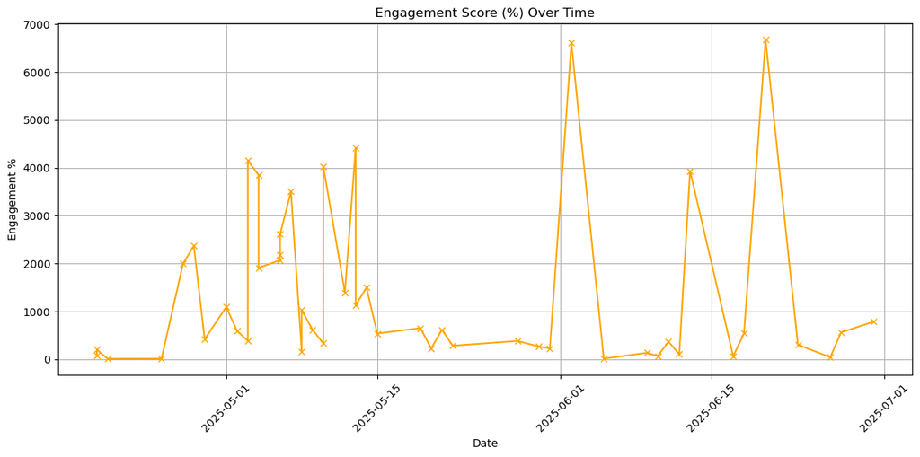

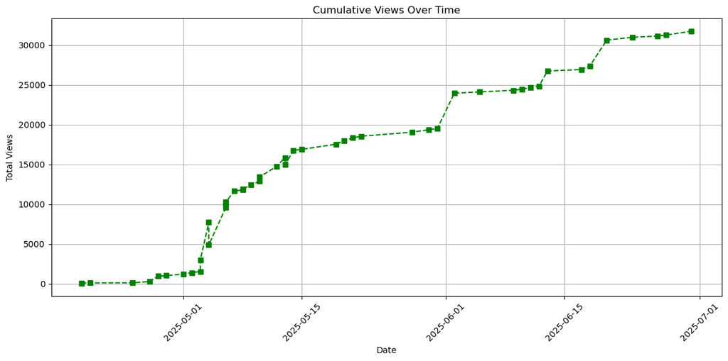

```python
# Engagement Score Over Time
plt.figure(figsize=(12,6))
plt.plot(df['Date Posted'], df['Engament Score %'], marker='x', linestyle='-', color='orange')
plt.title('Engagement Score (%) Over Time')
plt.xlabel('Date')
plt.ylabel('Engagement %')
plt.grid(True)
plt.xticks(rotation=45)
plt.tight_layout()
plt.savefig('engagement_over_time.png')
plt.show()

# Cumulative Views Over Time
plt.figure(figsize=(12,6))
plt.plot(df['Date Posted'], df['Cumulative Views'], marker='s', linestyle='--', color='green')
plt.title('Cumulative Views Over Time')
plt.xlabel('Date')
plt.ylabel('Total Views')
plt.grid(True)
plt.xticks(rotation=45)
plt.tight_layout()
plt.savefig('cumulative_views.png')
plt.show()
```

## Step 9: Exporting Visuals and Organizing Files

I save each visualization as a PNG image so I can easily include them in presentations, reports, or online portfolios.

Keeping my files organized (data, images, code, documentation) ensures a professional workflow that’s easy to maintain and share.

```python
# Images are saved already with plt.savefig() in previous cells.
# Here is an example to confirm files saved (optional):
import os

print("Saved Images:")
for filename in ['views_over_time.png', 'engagement_over_time.png', 'cumulative_views.png']:
    print(f" - {filename}: {'Exists' if os.path.exists(filename) else 'Missing'}")
```

```
Saved Images:
 - views_over_time.png: Exists
 - engagement_over_time.png: Exists
 - cumulative_views.png: Exists
```

## Step 10: Final Thoughts and Next Steps

This project allowed me to combine Excel and Python to perform a comprehensive analysis of my TikTok Live data.

Next, I plan to refine my Word report, adding these visuals and detailed explanations, and enhance my GitHub README with the insights and code walkthrough.

Finally, I will leverage this project to demonstrate my data storytelling and analytical skills in my job application.